# Projeto Adventure Works

## Modelos

A **Adventure Works** enfrenta desafios no `gerenciamento de demanda` e na `otimização da distribuição`. Para a empresa, prever a demanda com mais precisão é crucial para otimizar a produção e a logística. A intenção é demonstrar como uma `abordagem preditiva`, baseada em aprendizado de máquina, pode trazer mais vantagens e assertividade em comparação às práticas existentes.

Apresentamos os resultados do desenvolvimento de modelos de previsão de vendas e controle de suprimentos da Adventure Works para o `terceiro trimestre de 2014`. Foram utilizados modelos de séries temporais da biblioteca **Prophet** do Facebook, que se mostraram eficientes para capturar padrões de sazonalidade e tendência nos dados.

## Etapas

**Extração e Transformação dos Dados**: Os dados de vendas foram extraídos de um Databricks SQL Warehouse e carregados em um DataFrame do Pandas. As colunas de datas foram convertidas para o formato datetime e os dados foram agregados por diferentes granularidades de tempo (diário, mensal e trimestral).

**Análise de Outliers**: A presença de outliers foi identificada, principalmente em agregações diárias. A remoção desses pontos foi testada e considerada em alguns modelos para melhorar a precisão.

**Modelagem Preditiva**: Foi utilizado o Prophet para criar modelos de previsão para:

- Receita global de vendas;
- Quantidade global de produtos vendidos;
- Quantidade de luvas vendidas para estimar a necessidade de produção;
- Quantidade de produtos vendidos em cada combinação de "loja e produto";
- Receitas de dois centros (EUA e Resto do Mundo);
- Quantidade de zíperes para suprir a produção de luvas;

**Ajuste de Modelos**: Foram realizados testes com diferentes agregações de tempo (mensal e trimestral) e com a remoção de outliers. Os melhores modelos para cada cenário foram selecionados com base na aderência dos dados.

**Previsões e Resultados**: Com os modelos definidos, foram realizadas as previsões para o terceiro trimestre de 2014.

```python
import os
from dotenv import load_dotenv
from databricks import sql
import pandas as pd
import numpy as np
import seaborn as sns
import matplotlib.pyplot as plt
from prophet import Prophet
import statsmodels.api as sm
import sys
from contextlib import contextmanager
```

```python
@contextmanager
def suppress_stdout_stderr():
    with open(os.devnull, "w") as devnull:
        old_stdout, old_stderr = sys.stdout, sys.stderr
        sys.stdout, sys.stderr = devnull, devnull
        try:
            yield
        finally:
            sys.stdout, sys.stderr = old_stdout, old_stderr
```

```python
# Carrega as variáveis de ambiente do arquivo .env
load_dotenv()

# Acessando as variáveis
server_hostname = os.getenv("DATABRICKS_HOST")
http_path = os.getenv("DATABRICKS_HTTP_PATH")
access_token = os.getenv("DATABRICKS_TOKEN")
catalog = os.getenv("DATABRICKS_CATALOG")
mart_schema = os.getenv("DATABRICKS_SCHEMA_MARTS")
```

```python
# Query SQL para selecionar todos os dados da sua tabela
query = f"SELECT * FROM {catalog}.{mart_schema}.agg_sales_by_time"
query2 = f"SELECT * FROM {catalog}.{mart_schema}.dim_sales_cost"

try:
    # Conecte-se ao Databricks SQL Warehouse
    with sql.connect(server_hostname=server_hostname,
                     http_path=http_path,
                     access_token=access_token) as connection:

        # Crie um cursor para executar a query
        with connection.cursor() as cursor:
            # Execute a query
            cursor.execute(query)

            # Busque todos os resultados da query
            result = cursor.fetchall()

            # Obtenha os nomes das colunas para o DataFrame
            columns = [i[0] for i in cursor.description]

            # Crie o DataFrame do Pandas
            df = pd.DataFrame(result, columns=columns)

        with connection.cursor() as cursor:
            cursor.execute(query2)
            result = cursor.fetchall()
            columns = [i[0] for i in cursor.description]
            df2 = pd.DataFrame(result, columns=columns)

except Exception as e:
    print(f"Ocorreu um erro: {e}")
```

## Regressão linear

Utilizamos a receita líquida (net sales), pois os outros encargos de compra (frete e taxas) são custos esperados pelos clientes e, por isso, pouco determinante nas compras. Realizamos uma regressão linear para determinar se os valores dos encargos são influenciados pelo valor da compra.

```python
# Criando a coluna de engargos da compra a partir das colunas de frete e taxas
df2['charges'] = df2['tax_amount'] + df2['freight']

# Fazendo uma regressão linear entre receita líquida (net sales) e encargos
X = df2[['sub_total']]
y = df2['charges']
X = sm.add_constant(X)
model = sm.OLS(y, X).fit()
model.summary()
```

OLS Regression Results

| Dep. Variable: | charges | R-squared: | 0.997 |
| --- | --- | --- | --- |
| Model: | OLS | Adj. R-squared: | 0.997 |
| Method: | Least Squares | F-statistic: | 9.328e+06 |
| Date: | Thu, 04 Sep 2025 | Prob (F-statistic): | 0.00 |
| Time: | 01:41:13 | Log-Likelihood: | -1.8352e+05 |
| No. Observations: | 31465 | AIC: | 3.670e+05 |
| Df Residuals: | 31463 | BIC: | 3.671e+05 |
| Df Model: | 1 |  |  |
| Covariance Type: | nonrobust |  |  |

|  | coef | std err | t | P>\|t\| | [0.025 | 0.975] |
| --- | --- | --- | --- | --- | --- | --- |
| const | -22.4858 | 0.488 | -46.076 | 0.000 | -23.442 | -21.529 |
| sub_total | 0.1282 | 4.2e-05 | 3054.109 | 0.000 | 0.128 | 0.128 |

| Omnibus: | 83639.138 | Durbin-Watson: | 1.682 |
| --- | --- | --- | --- |
| Prob(Omnibus): | 0.000 | Jarque-Bera (JB): | 3041024191.607 |
| Skew: | 31.852 | Prob(JB): | 0.00 |
| Kurtosis: | 1524.673 | Cond. No. | 1.22e+04 |

Notes:  
[1] Standard Errors assume that the covariance matrix of the errors is correctly specified.  
[2] The condition number is large, 1.22e+04. This might indicate that there are  
strong multicollinearity or other numerical problems.

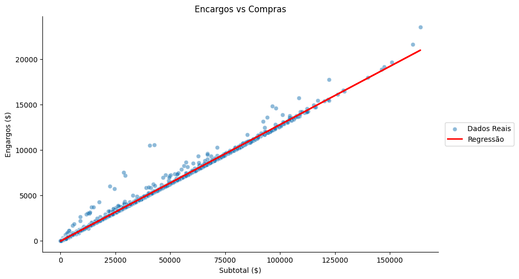

```python
X = df2['sub_total']

# Equação: y = intercepto + coeficiente * X
y_pred = -22.4858 + (0.1282 * X)

# 3. Plotar o gráfico
plt.figure(figsize=(10, 6))

# Plotar os dados originais como pontos
ax = sns.scatterplot(x=X, y=y, alpha=0.5, label='Dados Reais')
ax.spines['top'].set_visible(False)
ax.spines['right'].set_visible(False)

# Plotar a linha de regressão
ax.plot(X, y_pred, color='red', linewidth=2, label='Regressão')

# Adicionar títulos e rótulos
ax.legend(loc='right', bbox_to_anchor=(1.2, 0.5))
ax.set_title('Encargos vs Compras')
ax.set_xlabel('Subtotal ($)')
ax.set_ylabel('Engargos ($)')
plt.show()
```

Com R-squared igual a 99,7%, β₁ igual 12,8% a e p-valor igual a 0, o modelo apresenta uma correlação altamente significativa e influente, onde o valor dos encargos representa 12,8% o valor da receita líquida.

## Distribuição diária

#### Receita global

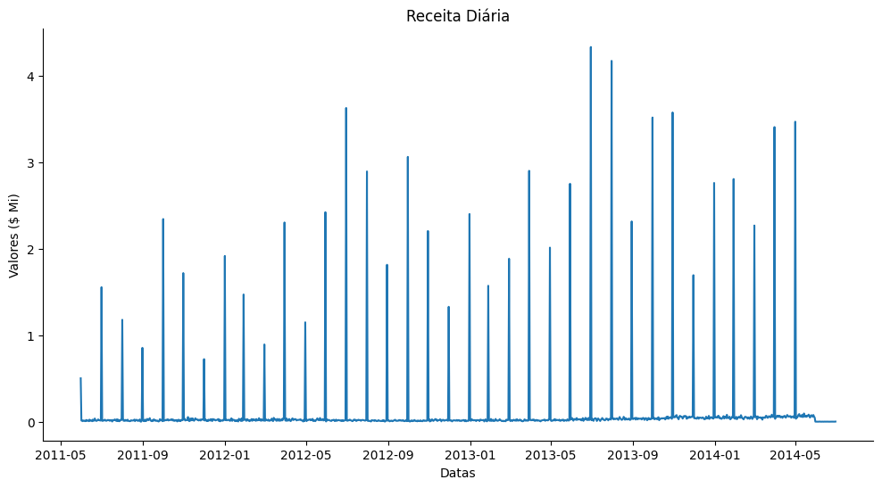

```python
# Transformando os dados de data em formato datetime
df['date_day'] = df['date_day'].dt.date
df['date_day'] = pd.to_datetime(df['date_day'])

# Agregando a receita de vendas por dia
df_sales_days = df.groupby('date_day').agg({'total_sales_amount': 'sum'}).reset_index()

# Distribuição diária da receita
plt.figure(figsize=(12,6))
ax = sns.lineplot(data=df_sales_days, x='date_day', y='total_sales_amount')
ax.spines['top'].set_visible(False)
ax.spines['right'].set_visible(False)
ax.get_yaxis().get_offset_text().set_visible(False)

# Adicionar títulos e rótulos
ax.set_title('Receita Diária')
ax.set_xlabel('Datas')
ax.set_ylabel('Valores ($ Mi)')
plt.show()
```

#### Produtos Vendidos

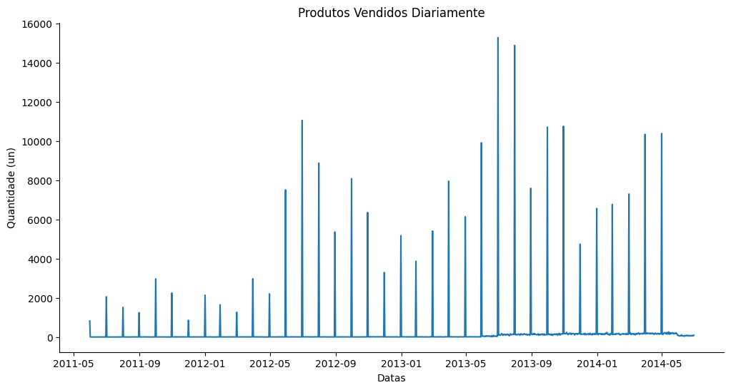

```python
# Agregando a quantidade de produtos vendidos por dia
df_qty_days = df.groupby('date_day').agg({'total_order_quantity': 'sum'}).reset_index()

# Distribuição diária da quantidade de produtos
plt.figure(figsize=(12,6))
ax = sns.lineplot(data=df_qty_days, x='date_day', y='total_order_quantity')
ax.spines['top'].set_visible(False)
ax.spines['right'].set_visible(False)

# Adicionar títulos e rótulos
ax.set_title('Produtos Vendidos Diariamente')
ax.set_xlabel('Datas')
ax.set_ylabel('Quantidade (un)')
plt.show()
```

Os dados de receita e de quantidade de produtos vendidos estão concentrados em poucos dias. Isso acontece devido ao registro das compras ocorrer no útimo dia do mês em quase toda sua totalidade. Essa configuração gerou modelos preditivos com pouca aderência.

## Distribuição mensal

##### Receita global

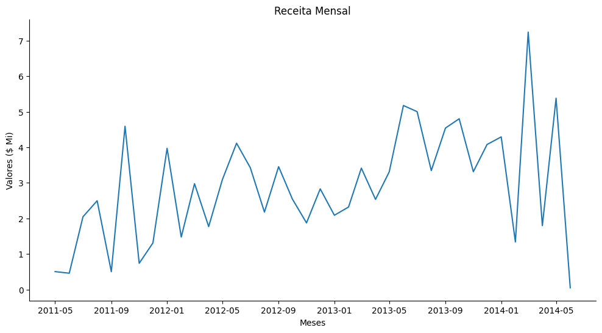

```python
# Agregando a receita de vendas por mês
df["month_year"] = df["date_day"].dt.to_period("M").dt.to_timestamp()
df_sales_month= df.groupby('month_year').agg({'total_sales_amount': 'sum'}).reset_index()

# Distribuição mensal da receita
plt.figure(figsize=(12,6))
ax = sns.lineplot(data=df_sales_month, x='month_year', y='total_sales_amount')
ax.spines['top'].set_visible(False)
ax.spines['right'].set_visible(False)
ax.get_yaxis().get_offset_text().set_visible(False)

# Adicionar títulos e rótulos
ax.set_title('Receita Mensal')
ax.set_xlabel('Meses')
ax.set_ylabel('Valores ($ Mi)')
plt.show()
```

##### Produtos Vendidos

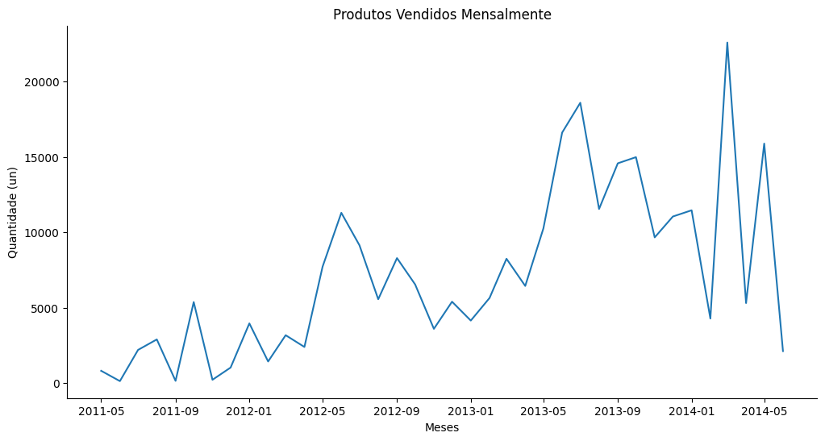

```python
# Agregando a quantidade de produtos vendidos por mês
df_qty_month = df.groupby('month_year').agg({'total_order_quantity': 'sum'}).reset_index()

# Distribuição mensal da quantidade de produtos
plt.figure(figsize=(12,6))
ax = sns.lineplot(data=df_qty_month, x='month_year', y='total_order_quantity')
ax.spines['top'].set_visible(False)
ax.spines['right'].set_visible(False)

# Adicionar títulos e rótulos
ax.set_title('Produtos Vendidos Mensalmente')
ax.set_xlabel('Meses')
ax.set_ylabel('Quantidade (un)')
plt.show()
```

A disposição dos dados de receita e de quantidade de produtos vendidos apresentam uma configuração mais padronizada, estável e intuitiva. Essa configuração permitiu o desenvolvimento de modelos preditivos mais confiáveis para receita e quantidade produtos vendidos, comparação entre os dois centros de distribuição (EUA X Resto do Mundo) e quantidade de luvas vendidas.

## Distribuição trimestral

##### Quantidade de Logo Caps Vendidos

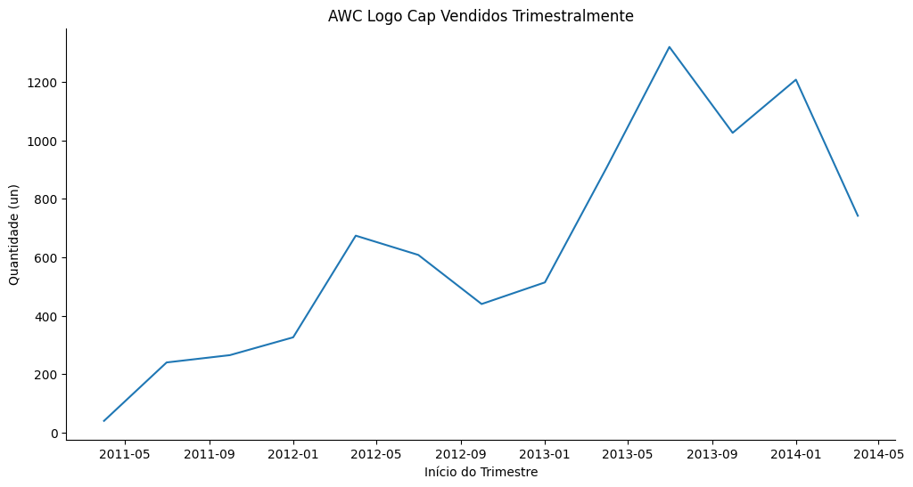

```python
# Agrupando a quantidade de bonés vendidos por trimestre
df_cap_quarter = df.loc[df['product_name'] == 'AWC Logo Cap', ['date_day', 'total_order_quantity']].copy().sort_values(by='date_day').reset_index(drop=True)
df_cap_quarter["quarter_year"] = df_cap_quarter["date_day"].dt.to_period("Q").dt.to_timestamp()
df_cap_quarter = df_cap_quarter.groupby("quarter_year").agg({"total_order_quantity": "sum"}).reset_index()

# Distribuição mensal da quantidade de produtos
plt.figure(figsize=(12,6))
ax = sns.lineplot(data=df_cap_quarter, x='quarter_year', y='total_order_quantity')
ax.spines['top'].set_visible(False)
ax.spines['right'].set_visible(False)

# Adicionar títulos e rótulos
ax.set_title('AWC Logo Cap Vendidos Trimestralmente')
ax.set_xlabel('Início do Trimestre')
ax.set_ylabel('Quantidade (un)')
plt.show()
```

Nos casos de quantidade de determinado produto (testado em AWC Logo Cap) e de quantidade de produto por loja, a disposição trimestral gerou melhores modelos. Isso ocorreu devido a falta de registro de compra em alguns meses.

## Modelos

### Receita Global

O melhor modelo apresentado foi o de `agregação mensal` e `sem remoção dos outliers`

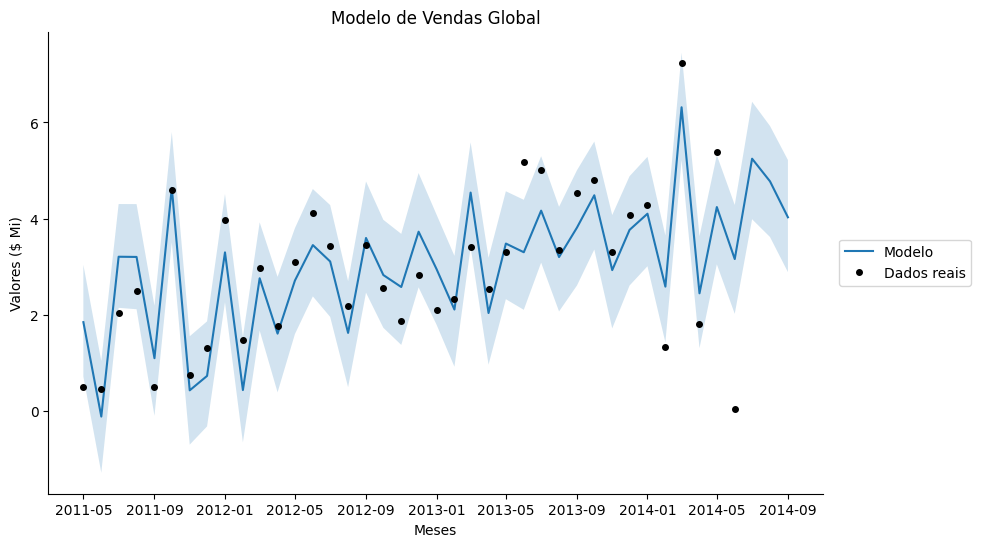

```python
# Desenvolvendo o modelo
df_prophet_sales_month = df_sales_month.rename(columns={'month_year': 'ds', 'total_sales_amount': 'y'})

np.random.seed(3678)
with suppress_stdout_stderr():
    model = Prophet()
    model.fit(df_prophet_sales_month)
future = model.make_future_dataframe(periods=3, freq='MS')
forecast = model.predict(future)
fig, ax = plt.subplots(figsize=(10, 6))

# Plotagem da previsão do modelo
ax.plot(forecast['ds'], forecast['yhat'], label='Modelo')
ax.fill_between(forecast['ds'], forecast['yhat_lower'], forecast['yhat_upper'], alpha=0.2)
ax.plot(df_prophet_sales_month['ds'], df_prophet_sales_month['y'], 'o', color='black', markersize=4, label='Dados reais')

# Configurações do gráfico
ax.spines['top'].set_visible(False)
ax.spines['right'].set_visible(False)
ax.get_yaxis().get_offset_text().set_visible(False)
ax.set_title('Modelo de Vendas Global')
ax.set_xlabel('Meses')
ax.set_ylabel('Valores ($ Mi)')
plt.legend(loc='right', bbox_to_anchor=(1.2, 0.5))
plt.show()
```

```python
q3_amount_forecast = forecast['yhat'][-3:].sum()
print(f'Previsão de receita para jul/2014: ${forecast["yhat"].to_list()[-3]:,.2f}')
print(f'Previsão de receita para ago/2014: ${forecast["yhat"].to_list()[-2]:,.2f}')
print(f'Previsão de receita para set/2014: ${forecast["yhat"].to_list()[-1]:,.2f}')
print()
print(f'Previsão total de receita para o 3º trimestre de 2014: ${q3_amount_forecast:,.2f}')
```

```
Previsão de receita para jul/2014: $5,244,869.72
Previsão de receita para ago/2014: $4,774,025.87
Previsão de receita para set/2014: $4,026,308.98

Previsão total de receita para o 3º trimestre de 2014: $14,045,204.57
```

### Quantidade de Produtos Vendidos

O melhor modelo apresentado foi o de `agregação mensal` e `com outliers removidos`

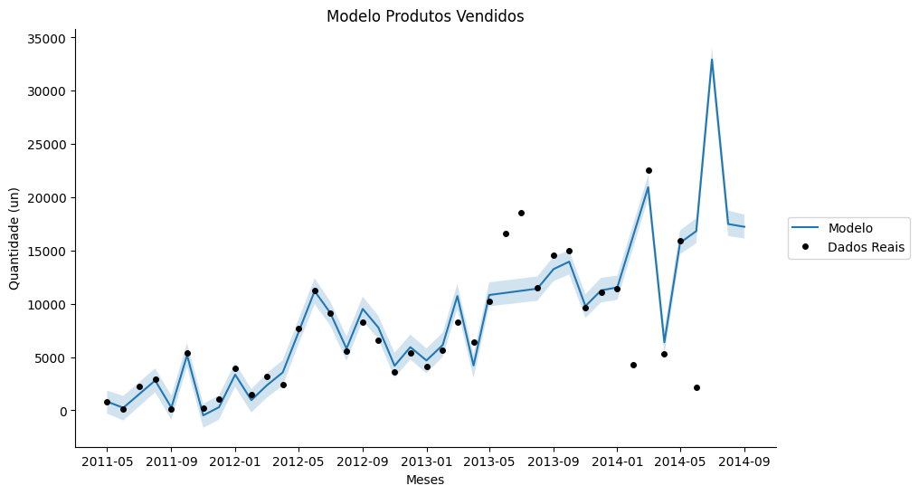

```python
df_prophet_qty_month = df_qty_month.rename(columns={'month_year': 'ds', 'total_order_quantity': 'y'})

np.random.seed(3678)
with suppress_stdout_stderr():
    model = Prophet()
    model.fit(df_prophet_qty_month)
future = model.make_future_dataframe(periods=0, freq='MS')
forecast = model.predict(future)

no_outliers = df_prophet_qty_month[(df_prophet_qty_month['y'] > forecast['yhat_lower']) & (df_prophet_qty_month['y'] < forecast['yhat_upper'])].reset_index(drop=True)
no_outliers

with suppress_stdout_stderr():
    model = Prophet()
    model.fit(no_outliers)
future = model.make_future_dataframe(periods=4, freq='MS')
forecast = model.predict(future)
fig, ax = plt.subplots(figsize=(10, 6))

ax.plot(forecast['ds'], forecast['yhat'], label='Modelo')
ax.fill_between(forecast['ds'], forecast['yhat_lower'], forecast['yhat_upper'], alpha=0.2)
ax.plot(df_prophet_qty_month['ds'], df_prophet_qty_month['y'], 'o', color='black', markersize=4, label='Dados Reais')

ax.spines['top'].set_visible(False)
ax.spines['right'].set_visible(False)
ax.set_title('Modelo Produtos Vendidos')
ax.set_xlabel('Meses')
ax.set_ylabel('Quantidade (un)')
plt.legend(loc='right', bbox_to_anchor=(1.2, 0.5))
plt.show()
```

```python
q3_amount_forecast = int(np.round(forecast['yhat'][-3:].sum(), 0))
print(f'Previsão de produtos vendidos para jul/2014: {int(np.round(forecast["yhat"].to_list()[-3], 0))}')
print(f'Previsão de produtos vendidos para ago/2014: {int(np.round(forecast["yhat"].to_list()[-2], 0))}')
print(f'Previsão de produtos vendidos para set/2014: {int(np.round(forecast["yhat"].to_list()[-1], 0))}')
print()
print(f'Previsão total de produtos vendidos para o 3º trimestre de 2014: {q3_amount_forecast:,.0f}')
```

```
Previsão de produtos vendidos para jul/2014: 32938
Previsão de produtos vendidos para ago/2014: 17494
Previsão de produtos vendidos para set/2014: 17232

Previsão total de produtos vendidos para o 3º trimestre de 2014: 67,663
```

### Sazonalidade de AWC Logo Cap

O melhor modelo apresentado foi o de `agregação trimestral` e `com sazonalidade anual`

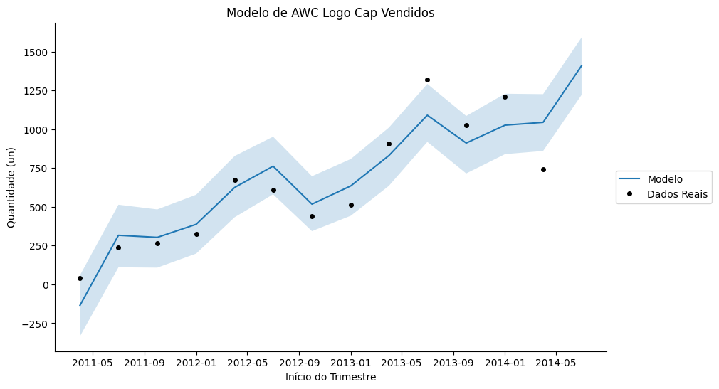

```python
df_prophet_qty_cap_quarter = df_cap_quarter.rename(columns={'quarter_year': 'ds', 'total_order_quantity': 'y'})

np.random.seed(3678)
with suppress_stdout_stderr():
    model = Prophet(yearly_seasonality=True)
    model.fit(df_prophet_qty_cap_quarter)
future = model.make_future_dataframe(periods=1, freq='QS')
forecast = model.predict(future)
fig, ax = plt.subplots(figsize=(10, 6))

ax.plot(forecast['ds'], forecast['yhat'], label='Modelo')
ax.fill_between(forecast['ds'], forecast['yhat_lower'], forecast['yhat_upper'], alpha=0.2)
ax.plot(df_prophet_qty_cap_quarter['ds'], df_prophet_qty_cap_quarter['y'], 'o', color='black', markersize=4, label='Dados Reais')

ax.spines['top'].set_visible(False)
ax.spines['right'].set_visible(False)
ax.set_title('Modelo de AWC Logo Cap Vendidos')
ax.set_xlabel('Início do Trimestre')
ax.set_ylabel('Quantidade (un)')
plt.legend(loc='right', bbox_to_anchor=(1.2, 0.5))
plt.show()
```

#### Sazonalidade trimestral

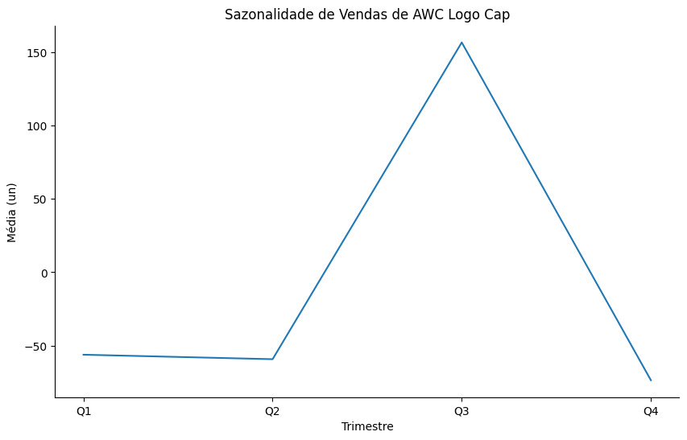

```python
forecast['quarter'] = forecast['ds'].dt.quarter
y_mean = (forecast['yearly'].mean())
forecast['yvar'] = [x - y_mean for x in forecast['yearly']]
forecast_quarter = forecast.groupby('quarter').agg({'yvar': 'mean'}).reset_index()
forecast_quarter['quarter'] = ['Q' + str(x) for x in forecast_quarter['quarter']]

fig, ax = plt.subplots(figsize=(10, 6))
ax.plot(forecast_quarter['quarter'], forecast_quarter['yvar'])
ax.spines['top'].set_visible(False)
ax.spines['right'].set_visible(False)

ax.set_title('Sazonalidade de Vendas de AWC Logo Cap')
ax.set_xlabel('Trimestre')
ax.set_ylabel('Média (un)')
plt.show()
```

```python
q3_amount_forecast = int(np.round(forecast['yhat'].to_list()[-1], 0))

print(f'Previsão total de AWC Logo Cap vendidos para o 3º trimestre de 2014: {q3_amount_forecast}')
```

```
Previsão total de AWC Logo Cap vendidos para o 3º trimestre de 2014: 1409
```

### Lojas e Seus Produtos

Removemos da modelagem as combinações "loja e produto" com menos de 37 produtos vendidos (um produto por mês), com a premissa de que os modelos seriam inviáveis nesses casos, e as previsões não seriam assertivas.

A partir do desenvolvimento de um modelo de um conjunto "loja e produto", o elegemos como ideal para todos os outros conjuntos. Dessa forma, modelamos todos os conjuntos usando o modelo elegido e armazenamos o resultado das previsões para o terceiro trimestre de 2014 em uma tabela. O modelo elegido foi o de `agregação trimestral` e `sem a remoção dos outliers`.

#### Tabela de Previsão de Vendas por Loja e Produto

```python
# Agregando todas as lojas e seus produtos
store_products = df.groupby(['store_name', 'product_name']).agg({'total_order_quantity': 'sum'}).reset_index()
store_products.columns = ['store', 'product', 'sold_quantity']

# Selecionando somente aqueles com mais de 36 produtos
store_products = store_products.loc[store_products['sold_quantity'] > 36].reset_index(drop=True)

# Criando um dataframe para armazenar as previsões por loja e produto
df_by_store_product = pd.DataFrame(columns=['Loja', 'Produto', 'Previsão de Vendas (un)'])

# Iterando sobre cada combinação de loja e produto para criar e aplicar o modelo
for _, row in store_products.iterrows():
    # Extraindo loja e produto
    model_store = row['store']
    model_product = row['product']

    # Filtrando os dados para a loja e produto específicos
    df_model = df.loc[(df['store_name'] == model_store) & (df['product_name'] == model_product), ['date_day', 'total_order_quantity']].copy().sort_values(by='date_day').reset_index(drop=True)
    df_model["quarter_year"] = df_model["date_day"].dt.to_period("Q").dt.to_timestamp()
    df_model = df_model.groupby("quarter_year").agg({"total_order_quantity": "sum"}).reset_index()

    # Preparando os dados para o Prophet
    df_prophet = df_model.rename(columns={'quarter_year': 'ds', 'total_order_quantity': 'y'})

    np.random.seed(3678)

    # Treinando o modelo e fazendo a previsão
    with suppress_stdout_stderr():
        model = Prophet()
        model.fit(df_prophet)
    future = model.make_future_dataframe(periods=1, freq='QS')
    forecast = model.predict(future)

    # Obtendo a previsão para o 3º trimestre de 2014
    q3_amount_forecast = int(np.round(forecast['yhat'].to_list()[-1], 0))

    # Adicionando os resultados ao dataframe
    df_support = pd.DataFrame({'Loja': [model_store], 'Produto': [model_product], 'Previsão de Vendas (un)': [q3_amount_forecast]})
    df_by_store_product = pd.concat([df_by_store_product, df_support], ignore_index=True)

df_by_store_product.loc[df_by_store_product['Previsão de Vendas (un)'] < 0, 'Previsão de Vendas (un)'] = 0
df_by_store_product
```

|  | Loja | Produto | Previsão de Vendas (un) |
| --- | --- | --- | --- |
| 0 | Action Bicycle Specialists | AWC Logo Cap | 4 |
| 1 | Action Bicycle Specialists | Classic Vest, M | 3 |
| 2 | Action Bicycle Specialists | Classic Vest, S | 17 |
| 3 | Action Bicycle Specialists | Short-Sleeve Classic Jersey, L | 3 |
| 4 | Action Bicycle Specialists | Short-Sleeve Classic Jersey, XL | 2 |
| ... | ... | ... | ... |
| 780 | World of Bikes | Women's Mountain Shorts, S | 14 |
| 781 | Worthwhile Activity Store | Women's Mountain Shorts, S | 5 |
| 782 | eCommerce Bikes | AWC Logo Cap | 15 |
| 783 | eCommerce Bikes | Long-Sleeve Logo Jersey, L | 5 |
| 784 | eCommerce Bikes | Sport-100 Helmet, Red | 7 |

785 rows × 3 columns

#### TOP10 Previsão de Vendas por Loja e Produto

```python
df_by_store_product.loc[df_by_store_product['Previsão de Vendas (un)'] > 25].sort_values(by='Previsão de Vendas (un)', ascending=False).reset_index(drop=True)
```

|  | Loja | Produto | Previsão de Vendas (un) |
| --- | --- | --- | --- |
| 0 | Brakes and Gears | Full-Finger Gloves, L | 52 |
| 1 | Resale Services | Full-Finger Gloves, L | 36 |
| 2 | Great Bikes | Women's Mountain Shorts, L | 33 |
| 3 | Latest Sports Equipment | Women's Mountain Shorts, L | 33 |
| 4 | Latest Sports Equipment | Women's Mountain Shorts, S | 33 |
| 5 | Rewarding Activities Company | AWC Logo Cap | 32 |
| 6 | Hardware Components | Long-Sleeve Logo Jersey, L | 31 |
| 7 | Casual Bicycle Store | Full-Finger Gloves, L | 29 |
| 8 | Fitness Sport Boutique | Full-Finger Gloves, L | 27 |
| 9 | Red Bicycle Company | Women's Mountain Shorts, L | 26 |

### EUA X Resto do Mundo

Para os diferentes centros de distribuição, tanto para os EUA quanto para o resto do mundo, os melhores modelos desenvolvidos foram os de `agregação mensal` e `sem remover os outliers`

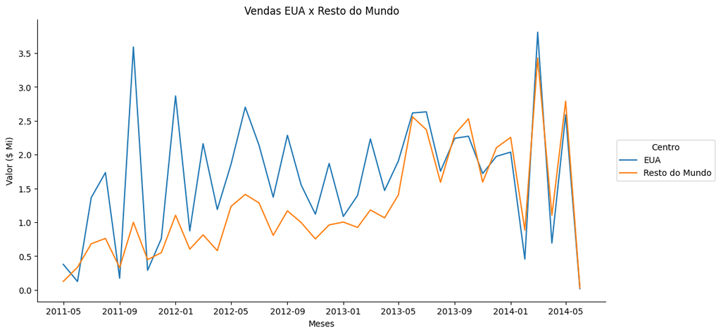

```python
# Criando uma coluna definindo em qual centro a venda foi realizada
df['center'] = ['EUA' if x == 'US' else 'Resto do Mundo' for x in df['country_region_code']]

# agregando os valores de venda por mês e por centro
df_data = df.groupby(['month_year', 'center']).agg({'total_sales_amount': 'sum'}).reset_index()
# Distribuição mensal dos dados de vendas

plt.figure(figsize=(12,6))
ax = sns.lineplot(data=df_data, x='month_year', y='total_sales_amount', hue='center')
ax.spines['top'].set_visible(False)
ax.spines['right'].set_visible(False)
ax.get_yaxis().get_offset_text().set_visible(False)
ax.legend(loc='right', bbox_to_anchor=(1.2, 0.5), title='Centro')

ax.set_title('Vendas EUA x Resto do Mundo')
ax.set_xlabel('Meses')
ax.set_ylabel('Valor ($ Mi)')
plt.show()
```

#### Comparação dos Modelos de Vendas EUA X Resto do Mundo

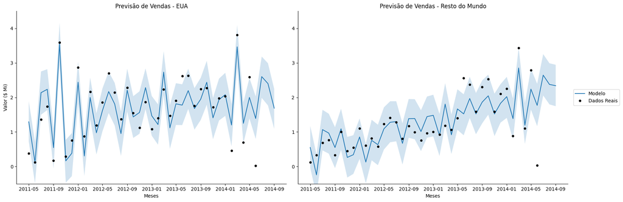

```python
# Preparando DF para modelo dos EUA
df_prophet_usa = df_data[df_data['center'] == 'EUA'].copy().reset_index(drop=True)
df_prophet_usa = df_prophet_usa[['month_year', 'total_sales_amount']]
df_prophet_usa = df_prophet_usa.rename(columns={'month_year': 'ds', 'total_sales_amount': 'y'})

# Preparando DF para modelo do resto do mundo
df_prophet_others = df_data[df_data['center'] == 'Resto do Mundo'].copy().reset_index(drop=True)
df_prophet_others = df_prophet_others[['month_year', 'total_sales_amount']]
df_prophet_others = df_prophet_others.rename(columns={'month_year': 'ds', 'total_sales_amount': 'y'})

# Criando o modelo dos EUA
with suppress_stdout_stderr():
        model_usa = Prophet()
        model_usa.fit(df_prophet_usa)
future_usa = model_usa.make_future_dataframe(periods=3, freq='MS')
forecast_usa = model_usa.predict(future_usa)

# Criando o modelo do resto do mundo
with suppress_stdout_stderr():
        model_others = Prophet()
        model_others.fit(df_prophet_others)
future_others = model_others.make_future_dataframe(periods=3, freq='MS')
forecast_others = model_others.predict(future_others)

# Criando uma figura com 1 linha e 2 colunas para os gráficos
fig, (ax1, ax2) = plt.subplots(1, 2, figsize=(18, 6))

# --- Gráfico do Modelo dos EUA (ax1) ---
ax1.plot(forecast_usa['ds'], forecast_usa['yhat'])
ax1.fill_between(forecast_usa['ds'], forecast_usa['yhat_lower'], forecast_usa['yhat_upper'], alpha=0.2)
ax1.plot(df_prophet_usa['ds'], df_prophet_usa['y'], 'o', markersize=4, color='black')

# Configurações do gráfico 1
ax1.spines['top'].set_visible(False)
ax1.spines['right'].set_visible(False)
ax1.get_yaxis().get_offset_text().set_visible(False)
ax1.set_ylim(-5e5, 4.5e6)
ax1.set_title('Previsão de Vendas - EUA')
ax1.set_xlabel('Meses')
ax1.set_ylabel('Valor ($ Mi)')

# --- Gráfico do Modelo do Resto do Mundo (ax2) ---
ax2.plot(forecast_others['ds'], forecast_others['yhat'], label='Modelo')
ax2.fill_between(forecast_others['ds'], forecast_others['yhat_lower'], forecast_others['yhat_upper'], alpha=0.2)
ax2.plot(df_prophet_others['ds'], df_prophet_others['y'], 'o', markersize=4, color='black', label='Dados Reais')

# Configurações do gráfico 2
ax2.spines['top'].set_visible(False)
ax2.spines['right'].set_visible(False)
ax2.get_yaxis().get_offset_text().set_visible(False)
ax2.set_ylim(-5e5, 4.5e6)
ax2.set_title('Previsão de Vendas - Resto do Mundo')
ax2.set_xlabel('Meses')
ax2.legend(loc='right', bbox_to_anchor=(1.2, 0.5))

# Ajuste automático do layout para evitar sobreposições
plt.tight_layout()
plt.show()
```

```python
trend_table_usa = forecast_usa[['ds', 'yhat']].copy()
trend_table_usa['center'] = 'USA'
trend_table_others = forecast_others[['ds', 'yhat']].copy()
trend_table_others['center'] = 'Others'

trend_table = pd.concat([trend_table_usa, trend_table_others], ignore_index=True)
trend_table = trend_table.pivot(index='ds', columns='center', values='yhat').reset_index()
trend_table = trend_table[['ds', 'USA', 'Others']].rename_axis(None, axis=1)

q3_amount_forecast_usa = trend_table['USA'][-3:].sum()
q3_amount_forecast_others = trend_table['Others'][-3:].sum()


print(f'Previsão total de vendas para o 3º trimestre de 2014 nos EUA: ${q3_amount_forecast_usa:,.2f}')
print(f'Previsão total de vendas para o 3º trimestre de 2014 no resto do mundo: ${q3_amount_forecast_others:,.2f}')
```

```
Previsão total de vendas para o 3º trimestre de 2014 nos EUA: $6,690,945.65
Previsão total de vendas para o 3º trimestre de 2014 no resto do mundo: $7,359,905.43
```

### Zíperes Para Luvas

O melhor modelo apresentado foi o de `agregação mensal` e `sem a remoção dos outliers`

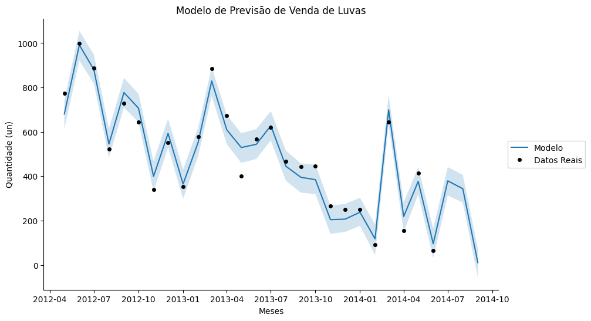

```python
# Agrupando a quantidade de bonés vendidos por trimestre
df_gloves_month = df.loc[df['product_subcategory_name'] == "Gloves", ['date_day', 'total_order_quantity']].copy().sort_values(by='date_day').reset_index(drop=True)
df_gloves_month["month_year"] = df_gloves_month["date_day"].dt.to_period("M").dt.to_timestamp()
df_gloves_month = df_gloves_month.groupby("month_year").agg({"total_order_quantity": "sum"}).reset_index()

df_prophet_gloves_month = df_gloves_month.rename(columns={'month_year': 'ds', 'total_order_quantity': 'y'})


np.random.seed(3678)
with suppress_stdout_stderr():
        model = Prophet()
        model.fit(df_prophet_gloves_month)
future = model.make_future_dataframe(periods=3, freq='MS')
forecast = model.predict(future)
fig, ax = plt.subplots(figsize=(10, 6))

ax.plot(forecast['ds'], forecast['yhat'], label='Modelo')
ax.fill_between(forecast['ds'], forecast['yhat_lower'], forecast['yhat_upper'], alpha=0.2)
ax.plot(df_prophet_gloves_month['ds'], df_prophet_gloves_month['y'], 'o', color='black', markersize=4, label='Datos Reais')

ax.spines['top'].set_visible(False)
ax.spines['right'].set_visible(False)
ax.set_title('Modelo de Previsão de Venda de Luvas')
ax.set_xlabel('Meses')
ax.set_ylabel('Quantidade (un)')
plt.legend(loc='right', bbox_to_anchor=(1.2, 0.5))
plt.show()
```

```python
q3_amount_forecast = int(np.round(forecast['yhat'][-3:].sum(), 0))

print(f'Subcategoria: Luvas')
print(f'Previsão total de produtos vendidos para o 3º trimestre de 2014: {q3_amount_forecast}')
print(f'Estimativa da quantidade de zíperes necessários para a produção global de luvas para o 3º trimestre de 2014: {2 * q3_amount_forecast}')
```

```
Subcategoria: Luvas
Previsão total de produtos vendidos para o 3º trimestre de 2014: 734
Estimativa da quantidade de zíperes necessários para a produção global de luvas para o 3º trimestre de 2014: 1468
```

## Resultados

### Previsões para o 3º trimestre de 2014

- Total de receita: **$14.045.204,57**
- Total de produtos vendidos: **67.663un**
- AWC Logo Cap vendidos: **1409un**
- Total de cada produto vendido em cada loja: `by_store_product.xlsx`
- Vendas nos EUA: **$6,690,945.65**
- Vendas no resto do mundo: **$7,359,905.43**
- Quantidade de zíperes necessários para a produção global de luvas: **1468un**

### Sazonalidades

AWC Logo Cap vendidos: **anual, com alta no terceiro trimestre**